# Resistance & recovery 4-sp communities: Analyze OD data

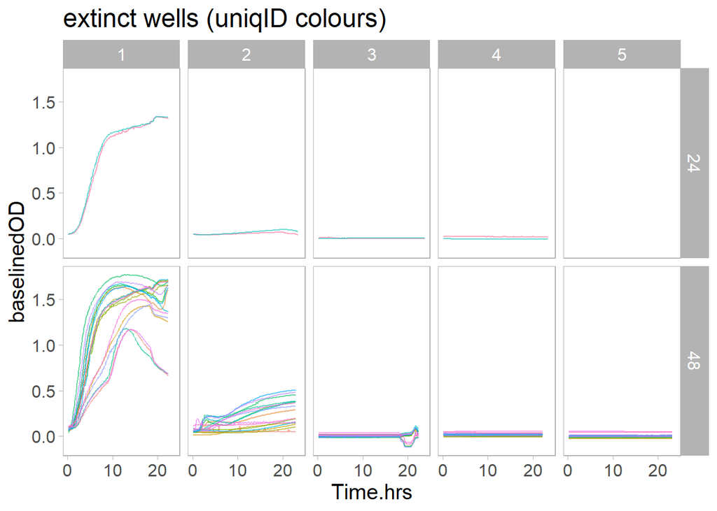

```r
# We can now confirm by eye that cutoff 2 works better than cutoff 1.

# keep the cutoff for future decisions
growth_cutoff <- cutoff2

# the last thing we need to do is to check which day was the last day when anything detectable grew
latest_time <- the.data %>% filter(uniqID %in% extinct_c2) # apply the better cutoff
# get the latest time when growth could still be detected in eventually extinct wells,
latest_time <- latest_time %>% filter(Time.hrs > 22) %>%
                  group_by(uniqID, Day, Heat) %>% summarise(finalOD = mean(baselinedOD)) %>%
                    filter(finalOD > growth_cutoff) %>% arrange(-Day) # largest Day will be at the top!!!
latest_time <- latest_time[!duplicated(latest_time$uniqID),] # the first instance corresponds with the very last time

# plot the samples that went extinct
ext_plot <- the.data %>% filter(uniqID %in% latest_time$uniqID)
ext_plot$uniqID <- factor(ext_plot$uniqID)
  # re-order to levels to better distinguish the 2 samples at 24hrs
ext_plot$uniqID <- factor(ext_plot$uniqID,
                          levels=c(levels(ext_plot$uniqID)[1:9], levels(ext_plot$uniqID)[19], levels(ext_plot$uniqID)[10:18]))
  # plot
ggplot(ext_plot,
       aes(x=Time.hrs, y=baselinedOD, group=uniqCurve, colour=uniqID)) +
  facet_grid(rows=vars(Heat), cols=vars(Day)) +
  geom_line(alpha=0.6) +
  scale_x_continuous(breaks=c(0,10,20)) +
  labs(title = "extinct wells (uniqID colours)") +
  theme(legend.position="none")
```

```r
# print out the extinct wells to file so that they can be used in analyze_temp_serial_transfer_expt--28Oct24.Rmd
write.csv(latest_time %>% select(uniqID, Day),
          file="./intermediate_data/extinctOD_wells.csv", quote=FALSE, row.names=FALSE)

rm(tmpData, cutoff1, cutoff2, extinct_c1, extinct_c2, latest_time, ext_plot)
```

Use the contaminated blank wells to estimate the rate of contamination across Dates (aka inoculum batches), unique Plates, and Days.

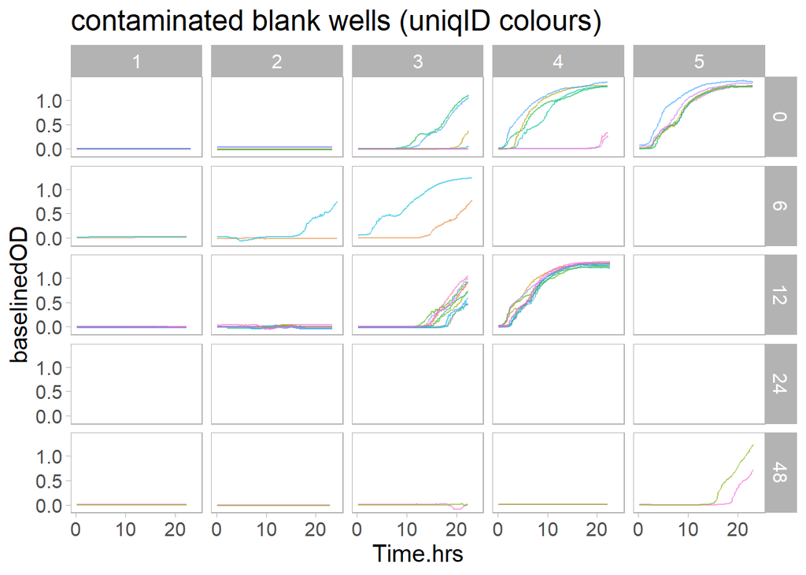

```r
# re-arrange some stuff in contaminated.blanks for cleaner plotting
contaminated.blanks$uniqID <- factor(contaminated.blanks$uniqID,
                                     levels=c("24-08-05 Epoch C6", "24-07-02 Epoch D8", "24-08-05 Epoch D6",  "24-07-08 Epoch G6",
                                              "24-08-05 Epoch D8", "24-07-08 H1 B6","24-08-05 Epoch D11", "24-07-08 Epoch C6",
                                              "24-08-05 Epoch E6", "24-07-08 Epoch E6", "24-08-05 Epoch E11", "24-07-02 Epoch H12",
                                              "24-08-05 Epoch F5", "24-07-08 Epoch H1", "24-08-05 Epoch F6",  "24-07-08 Epoch H3",
                                              "24-08-05 Epoch G6", "24-07-08 H1 A1",    "24-08-05 Epoch H3",  "24-07-08 Epoch B10"))
tmp <- data.frame(rep(NA,4),rep(NA,4),rep(NA,4), 1:4, rep(NA,4),rep(24,4),rep(NA,4),rep(NA,4),
                  rep(NA,4),rep(NA,4),rep(NA,4),rep(NA,4), rep(NA,4),rep(NA,4),rep(NA,4),rep(NA,4),
                  rep(NA,4),rep(NA,4),rep(NA,4))
colnames(tmp) <- colnames(contaminated.blanks)
contaminated.blanks <- rbind(contaminated.blanks, tmp)
rm(tmp)

# plot the unique contaminated blank wells
ggplot(contaminated.blanks,
       aes(x=Time.hrs, y=baselinedOD, group=uniqCurve, colour=uniqID)) +
  facet_grid(rows=vars(Heat), cols=vars(Day)) +
  geom_line(alpha=0.6) +
  scale_x_continuous(breaks=c(0,10,20)) +
  labs(title = "contaminated blank wells (uniqID colours)") +
  theme(legend.position="none")
```

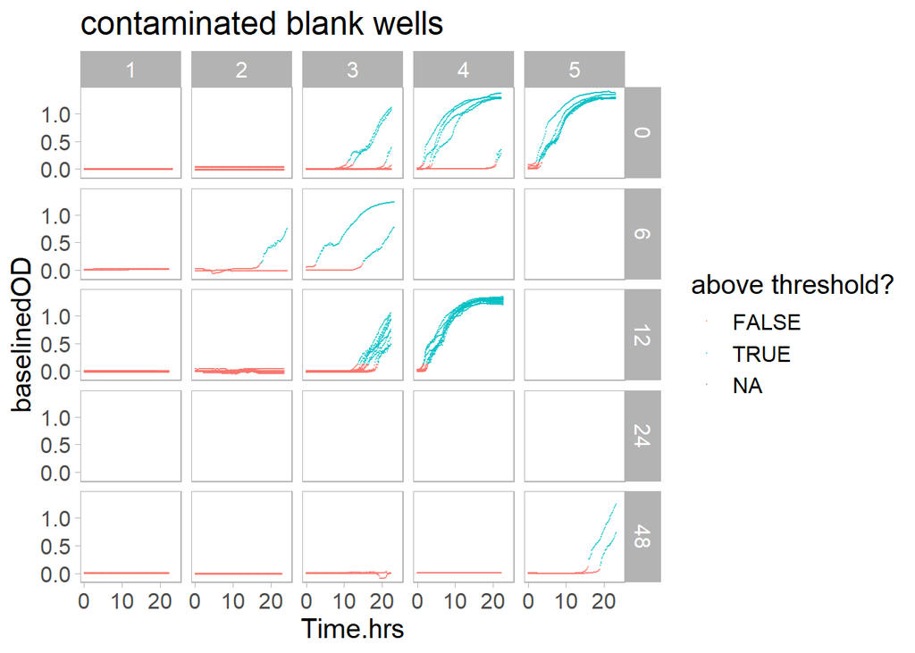

```r
# find the times when OD got higher than baseline
contaminated.blanks$detectTime <- contaminated.blanks$baselinedOD > growth_cutoff
# check growth_cutoff is working as expected:
ggplot(contaminated.blanks,
       aes(x=Time.hrs, y=baselinedOD, group=uniqCurve, colour=detectTime)) +
  facet_grid(rows=vars(Heat), cols=vars(Day)) +
  geom_point(alpha=0.5, size=0.1) +
  scale_x_continuous(breaks=c(0,10,20)) +
  labs(title = "contaminated blank wells", colour="above threshold?")
```

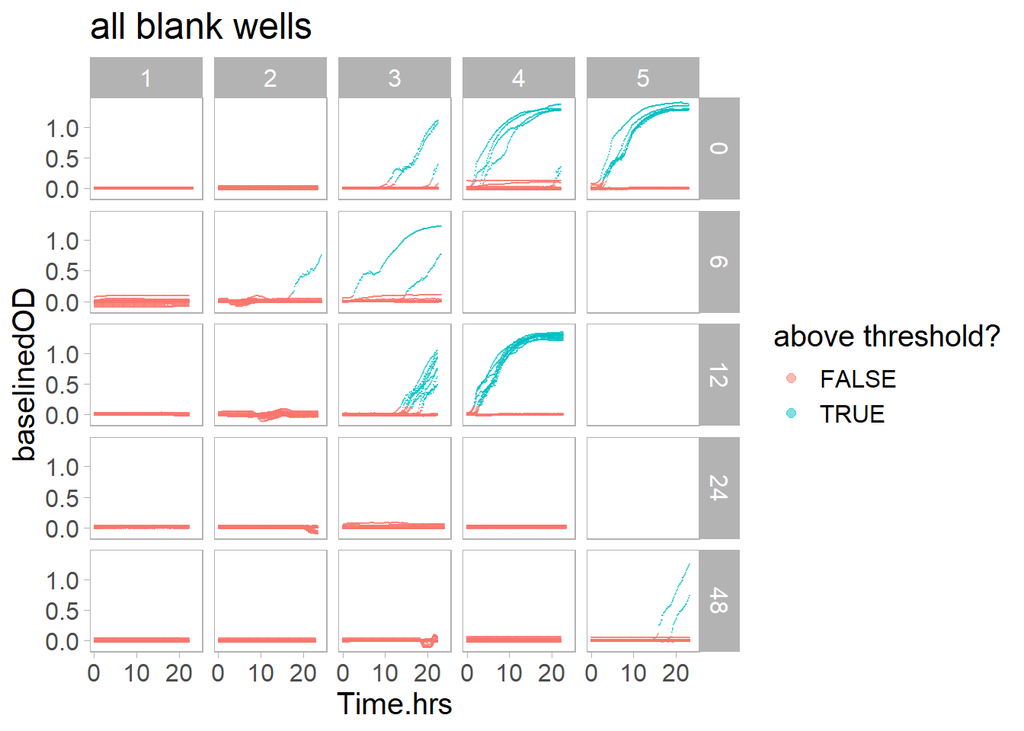

```r
# make a plot to show that the growth cutoff is reasonable for identifying contaminated blanks
ggplot(rbind(cbind(the.data, detectTime=FALSE), contaminated.blanks) %>% filter(CommRich == 0),
              aes(x=Time.hrs, y=baselinedOD, group=uniqCurve, colour=detectTime)) +
  facet_grid(rows=vars(Heat), cols=vars(Day)) +
  geom_point(alpha=0.5, size=0.1) +
  scale_x_continuous(breaks=c(0,10,20)) +
  labs(title = "all blank wells", colour="above threshold?") +
  guides(colour = guide_legend(override.aes = list(size=2)))
```

```r
# get the earliest time when contamination could be detected,
earliest_time <- contaminated.blanks %>% filter(detectTime==TRUE) %>% group_by(uniqID, Day) %>%
                    summarize(firstDetect = min(Time.hrs)) %>% arrange(uniqID, Day) %>%
                      rename(detectHr=firstDetect)
```

```r
earliest_time <- earliest_time[!duplicated(earliest_time$uniqID),] # the first instance corresponds with the very earliest time

# add the annotation back to the earliest contamination detection time
earliest_time <- left_join(earliest_time,
                           contaminated.blanks %>% select(uniqID, Day, Heat, Heat_Day, Recov_Day) %>% unique(),
                           by=c("uniqID", "Day"))
print(earliest_time) # print this table as it will be useful in its own right.
```

```
## # A tibble: 20 × 6
## # Groups:   uniqID [20]
##    uniqID               Day detectHr  Heat Heat_Day Recov_Day
##    <fct>              <int>    <dbl> <dbl>    <int>     <int>
##  1 24-08-05 Epoch C6      3    19.0     12       NA         1
##  2 24-07-02 Epoch D8      3    15.2      6       NA         2
##  3 24-08-05 Epoch D6      3    15.3     12       NA         1
##  4 24-07-08 Epoch G6      3    21.0      0       NA        NA
##  5 24-08-05 Epoch D8      3    16.5     12       NA         1
##  6 24-07-08 H1 B6         5    16.0     48       NA         2
##  7 24-08-05 Epoch D11     3    13.7     12       NA         1
##  8 24-07-08 Epoch C6      3    11.2      0       NA        NA
##  9 24-08-05 Epoch E6      3    16.2     12       NA         1
## 10 24-07-08 Epoch E6      4     4.15     0       NA        NA
## 11 24-08-05 Epoch E11     3    18.8     12       NA         1
## 12 24-07-02 Epoch H12     2    17.5      6       NA         1
## 13 24-08-05 Epoch F5      3    18.2     12       NA         1
## 14 24-07-08 Epoch H1      3    12.8      0       NA        NA
## 15 24-08-05 Epoch F6      3    14.5     12       NA         1
## 16 24-07-08 Epoch H3      4    21.2      0       NA        NA
## 17 24-08-05 Epoch G6      3    15.2     12       NA         1
## 18 24-07-08 H1 A1         5    19.0     48       NA         2
## 19 24-08-05 Epoch H3      3    15.5     12       NA         1
## 20 24-07-08 Epoch B10     4    20.8      0       NA        NA
```

```r
# summarize this information as a probability for each heat treatment
prob.heat <- earliest_time %>% group_by(Heat) %>% summarise(contEvents = n(), prob = n()/21)
prob.heat <- rbind(prob.heat, c(24, 0, 0))
print(prob.heat %>% arrange(Heat))
```

```
## # A tibble: 5 × 3
##    Heat contEvents   prob
##   <dbl>      <dbl>  <dbl>
## 1     0          6 0.286
## 2     6          2 0.0952
## 3    12         10 0.476
## 4    24          0 0
## 5    48          2 0.0952
```

```r
mean(prob.heat$prob)
```

```
## [1] 0.1904762
```

```r
# summarize this information as a probability for each day
prob.day <- earliest_time %>% group_by(Day) %>% summarise(contEvents = n())
prob.day <- rbind(c(1, 0), prob.day)
prob.day$total_reps <- c(rep(5*21,3), 4*21, 2*21) # there's different numbers of blank wells per day across the whole experiment
# because the days are sequential and wells can only be contaminated once,
# a contamination event that occurred on Day 2 will decrease the total number of blank wells for all subsequent days
for(i in 1:nrow(prob.day)){
  #therefore, adjust the total reps for each day to take into account previously contaminated wells
  prob.day$total_reps[i] <- prob.day$total_reps[i]-sum(prob.day$contEvents[1:i])
}
prob.day <- prob.day %>% mutate(prob = contEvents/total_reps, .keep="all")
print(prob.day)
```

```
## # A tibble: 5 × 4
##     Day contEvents total_reps    prob
##   <dbl>      <dbl>      <dbl>   <dbl>
## 1     1          0        105 0
## 2     2          1        104 0.00962
## 3     3         14         90 0.156
## 4     4          3         66 0.0455
## 5     5          2         22 0.0909
```

```r
# cleanup
rm(contaminated.blanks, earliest_time, i, prob.day, prob.heat)
```

# Plot the data

Before we can plot the data, we need to load the information about which replicates were identified by flow cytometry as having been contaminated. (e.g., Otherwise we might think that there was growth in a slow growing well when in fact it was just P. protegens contamination…).

To do this, we will load in the `absDensity` data file from `main_expt--flow_cytometry_analysis.Rmd`. This contains the absolute densities from only the finalized dataset – i.e., where all the contaminated replicates have been removed! We are going to use just the uniqID’s from this finalized dataset.

```r
# load the absDensity data frame
load("./intermediate_data/absolute_density_data.RData")

# keep the OD data only for uniqID's that are found in absDensity
the.data <- the.data %>% filter(uniqID %in% unique(absDensity$uniqID))

rm(absDensity)
```

Now we can go ahead and plot the OD over time from the finalized dataset:

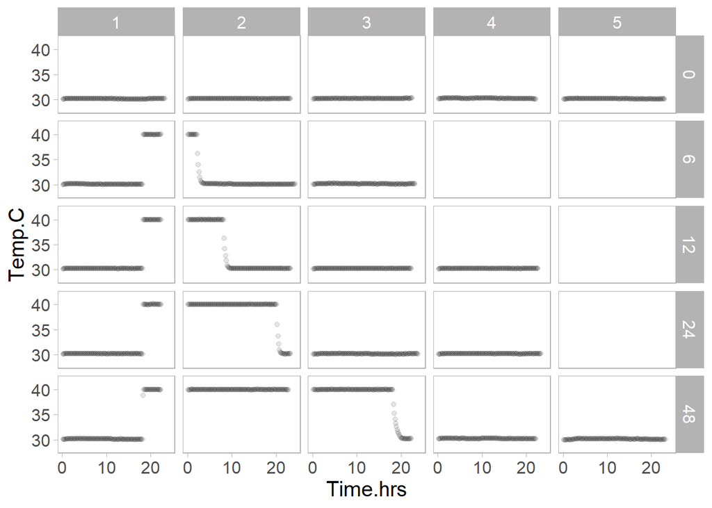

```r
ggplot(the.data %>% select(Date, Day, Heat, Time.hrs, Temp.C) %>% distinct(),
       aes(x=Time.hrs, y=Temp.C)) +
  facet_grid(rows=vars(Heat), cols=vars(Day)) +
  geom_point(alpha=0.1) +
  scale_y_continuous(limits=c(28,42), breaks=c(30,35,40)) +
  scale_x_continuous(breaks=c(0,10,20))
```

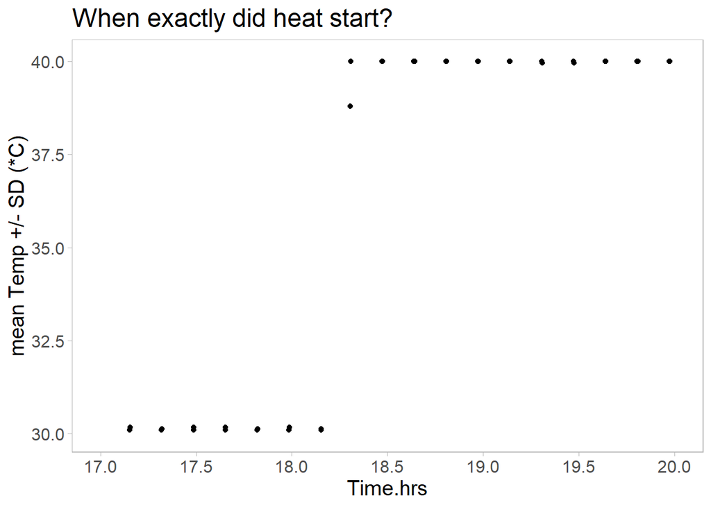

```r
# extract some information about exact timing of temperature for model fitting
ggplot(the.data %>% filter(Day==1, Heat!=0) %>%
        ungroup() %>% group_by(Time.hrs) %>% summarise(meanTemp=mean(Temp.C),
                                                       sdTemp=sd(Temp.C)),
       aes(x=Time.hrs, y=meanTemp))+
  geom_errorbar(aes(ymin=meanTemp-sdTemp, ymax=meanTemp+sdTemp))+
  scale_x_continuous(limits=c(17,20), breaks=seq(from=17,to=20,by=0.5)) +
  geom_point() +
  labs(y="mean Temp +/- SD (*C)",
       title="When exactly did heat start?")
```

```r
# how long was each day on average?
tmp <- the.data %>% ungroup() %>% group_by(Day, Heat) %>%
          summarise(maxTime=max(Time.hrs))
```

[output not shown]

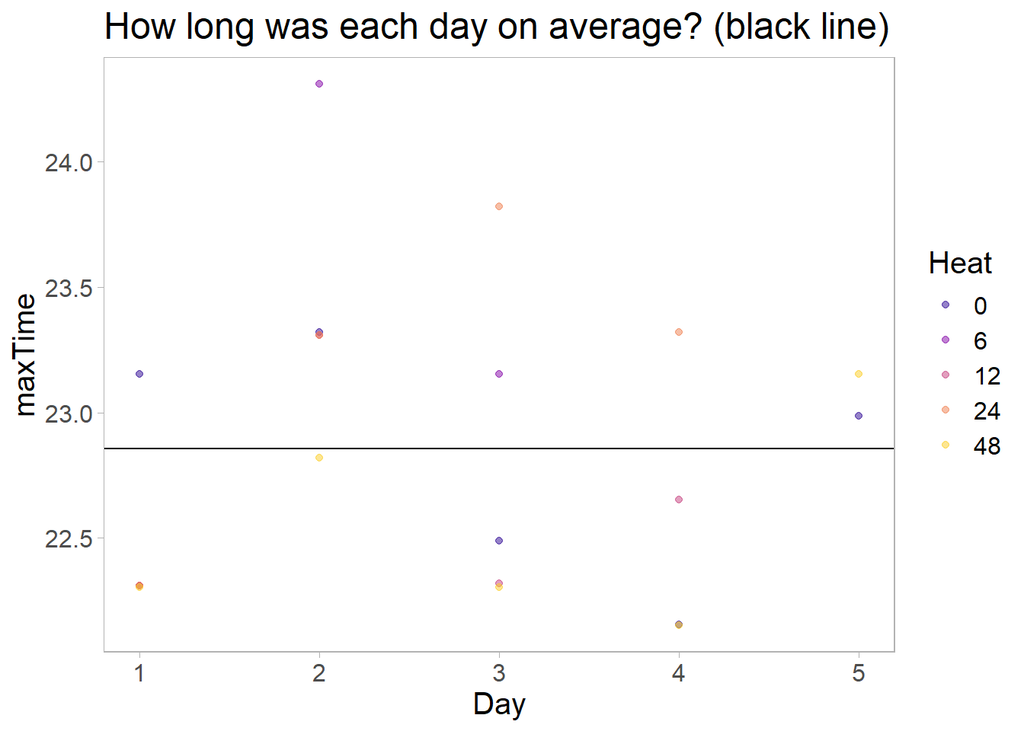

```r
ggplot(tmp, aes(x=Day, y=maxTime, colour=as.factor(Heat))) +
  geom_point(alpha=0.5) +
  geom_hline(yintercept=mean(tmp$maxTime))+
  control_to_48h_pal +
  labs(colour="Heat", title="How long was each day on average? (black line)")
```

```r
mean(tmp$maxTime)
```

```
## [1] 22.85556
```

```r
rm(tmp)

# how long was each heat event
the.data %>% filter(Heat!=0, Temp.C>35) %>% ungroup() %>%
  group_by(Heat, Day) %>% summarise(minHeatT=min(Time.hrs),
                                    maxHeatT=max(Time.hrs))
```

| Heat | Day | minHeatT | maxHeatT |
| --- | --- | --- | --- |
| 6 | 1 | 18.3088889 | 22.308889 |
| 6 | 2 | 0.1544444 | 2.308889 |
| 12 | 1 | 18.3088889 | 22.308889 |
| 12 | 2 | 0.1544444 | 8.308889 |
| 24 | 1 | 18.3088889 | 22.308889 |
| 24 | 2 | 0.1544444 | 20.308889 |
| 48 | 1 | 18.3055556 | 22.305556 |
| 48 | 2 | 0.1527778 | 22.819444 |
| 48 | 3 | 0.1527778 | 18.472222 |

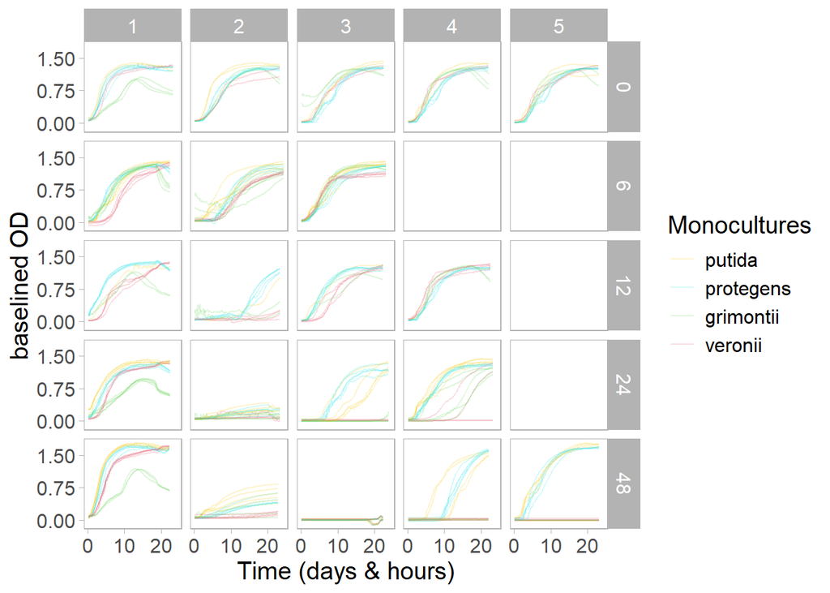

```r
### THIS NEEDS TO BE CHANGED!!!
  # I have no idea what needs to be changed about this but okay??
temp <- the.data
temp[which(the.data$Day==1 & the.data$Heat==0 & the.data$CommRich==1 & the.data$protegens==1),c(10, 19)] <- temp[which(the.data$Day==1 & the.data$Heat==0 & the.data$CommRich==2 & the.data$putida==1 & the.data$veronii==1),c(10,19)]
temp[which(the.data$Day==1 & the.data$Heat==48 & the.data$CommRich==1 & the.data$protegens==1),c(10, 19)] <- temp[which(the.data$Day==1 & the.data$Heat==48 & the.data$CommRich==2 & the.data$putida==1 & the.data$veronii==1),c(10,19)]
temp <- temp %>% filter(CommRich==1) %>% unite(community, putida:veronii)
temp$community[which(temp$community == "1_0_0_0")] <- "putida"
temp$community[which(temp$community == "0_1_0_0")] <- "protegens"
temp$community[which(temp$community == "0_0_1_0")] <- "grimontii"
temp$community[which(temp$community == "0_0_0_1")] <- "veronii"
temp$community <- factor(temp$community,
                         levels=c("putida", "protegens", "grimontii", "veronii"))
ggplot(temp,
       aes(x=Time.hrs, y=baselinedOD, group=uniqCurve, colour=community)) +
  facet_grid(rows=vars(Heat), cols=vars(Day)) +
  geom_line(alpha=0.2) +
  scale_y_continuous(breaks=c(0, 0.75, 1.5)) +
  scale_x_continuous(breaks=c(0,10,20)) +
  scale_colour_manual(values=species_4pal[c(3,2,1,4)]) +
  labs(colour="Monocultures", y="baselined OD", x="Time (days & hours)")
```

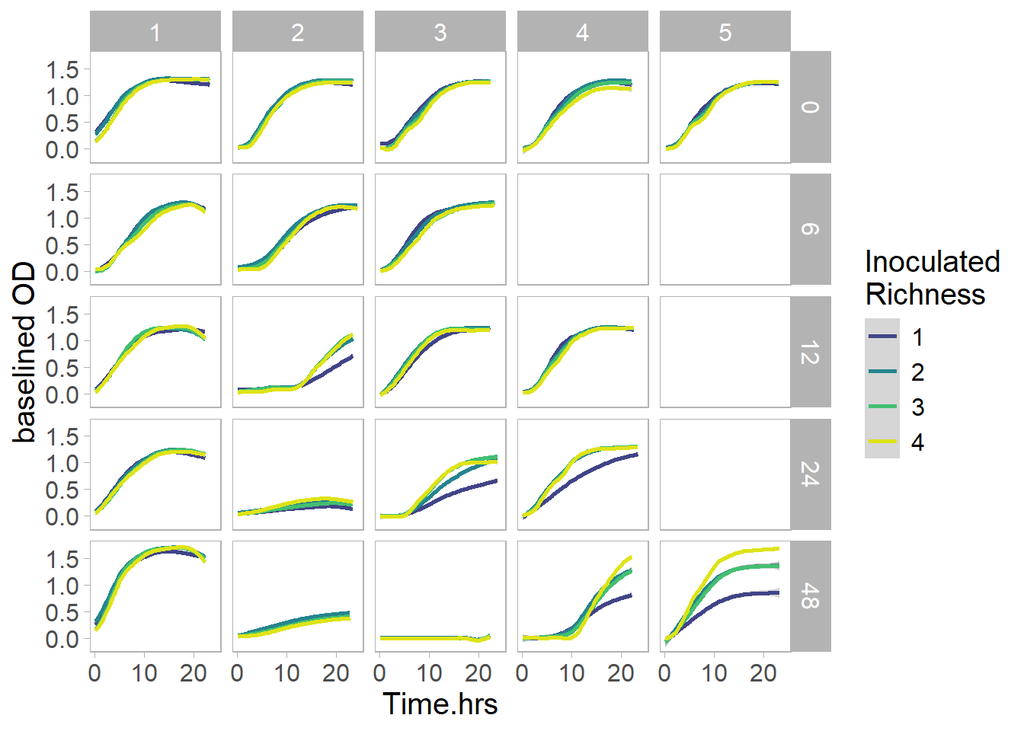

```r
ggplot(the.data %>% filter(CommRich>0),
       aes(x=Time.hrs, y=baselinedOD, group=uniqCurve, colour=as.factor(CommRich))) +
  facet_grid(rows=vars(Heat), cols=vars(Day)) +
  geom_smooth(aes(group=CommRich)) +
  scale_x_continuous(breaks=c(0,10,20)) +
  CommRich_pal +
  labs(colour="Inoculated\nRichness", y="baselined OD")
```